# Project_PMachLearn

Ruben Vivaldi Silva Pessoa

02/10/2020

## Coursera Practical Machine Learning Final Project

Ruben Pessoa

## I. Overview

This document is the final report of the Peer Assessment project from Coursera’s course Practical Machine Learning, as part of the Specialization in Data Science.It was built up in RStudio, using its knitr functions, meant to be published in html format. This analysis meant to be the basis for the course quiz and a prediction assignment writeup. The main goal of the project is to predict the manner in which 6 participants performed some exercise as described below. This is the “classe” variable in the training set. The machine learning algorithm described here is applied to the 20 test cases available in the test data and the predictions are submitted in appropriate format to the Course Project Prediction Quiz for automated grading.

## II. Background

Using devices such as Jawbone Up, Nike FuelBand, and Fitbit it is now possible to collect a large amount of data about personal activity relatively inexpensively. These type of devices are part of the quantified self movement - a group of enthusiasts who take measurements about themselves regularly to improve their health, to find patterns in their behavior, or because they are tech geeks. One thing that people regularly do is quantify how much of a particular activity they do, but they rarely quantify how well they do it. In this project, your goal will be to use data from accelerometers on the belt, forearm, arm, and dumbell of 6 participants. They were asked to perform barbell lifts correctly and incorrectly in five different ways.

## III. Data Loading and Exploratory Analysis

A short description of the datasets content from the authors’ website:

“Six young health participants were asked to perform one set of 10 repetitions of the Unilateral Dumbbell Biceps Curl in five different fashions: exactly according to the specification (Class A), throwing the elbows to the front (Class B), lifting the dumbbell only halfway (Class C), lowering the dumbbell only halfway (Class D) and throwing the hips to the front (Class E).

Class A corresponds to the specified execution of the exercise, while the other 4 classes correspond to common mistakes. Participants were supervised by an experienced weight lifter to make sure the execution complied to the manner they were supposed to simulate. The exercises were performed by six male participants aged between 20-28 years, with little weight lifting experience. We made sure that all participants could easily simulate the mistakes in a safe and controlled manner by using a relatively light dumbbell (1.25kg)."

## Setup

### Load packages

```r
library(caret)

## Loading required package: lattice

## Loading required package: ggplot2
library(knitr)
library(rpart)
library(rpart.plot)
library(RColorBrewer)
library(rattle)
library(caret)
library(randomForest)

library(corrplot)

library(gbm)
```

### Load data

**First:**

```r
# set the URL for the download
UrlTrain <- "http://d396qusza40orc.cloudfront.net/predmachlearn/pml-training.csv"
UrlTest  <- "http://d396qusza40orc.cloudfront.net/predmachlearn/pml-testing.csv"

# download the datasets
training <- read.csv(url(UrlTrain))
testing  <- read.csv(url(UrlTest))
```

## creating a partition with the training dataset

```r
inTrain  <- createDataPartition(training$classe, p=0.7, list=FALSE)
TrainSet <- training[inTrain, ]
TestSet  <- training[-inTrain, ]
dim(TrainSet)
```

```
## [1] 13737   160
```

```r
dim(TestSet)
```

```
## [1] 5885  160
```

Both created datasets have 160 variables. Those variables have plenty of NA, that can be removed with the cleaning procedures below. The Near Zero variance (NZV) variables are also removed and the ID variables as well.

```r
# remove variables with Nearly Zero Variance
NZV <- nearZeroVar(TrainSet)
TrainSet <- TrainSet[, -NZV]
TestSet  <- TestSet[, -NZV]
dim(TrainSet)
```

```
## [1] 13737   104
```

```r
dim(TestSet)
```

```
## [1] 5885  104
```

```r
# remove variables with Nearly Zero Variance
AllNA    <- sapply(TrainSet, function(x) mean(is.na(x))) > 0.95
TrainSet <- TrainSet[, AllNA==FALSE]
TestSet  <- TestSet[, AllNA==FALSE]
dim(TrainSet)
```

```
## [1] 13737    59
```

```r
dim(TestSet)
```

```
## [1] 5885   59
```

```r
# remove identification only variables (columns 1 to 5)
TrainSet <- TrainSet[, -(1:5)]
TestSet  <- TestSet[, -(1:5)]
dim(TrainSet)
```

```
## [1] 13737    54
```

```r
dim(TestSet)
```

```
## [1] 5885   54
```

## Correlation Analysis

A correlation among variables is analysed before proceeding to the modeling procedures.

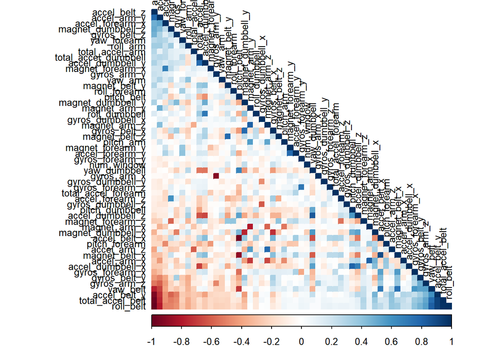

```r
corMatrix <- cor(TrainSet[, -54])
corrplot(corMatrix, order = "FPC", method = "color", type = "lower",
         tl.cex = 0.8, tl.col = rgb(0, 0, 0))
```

The highly correlated variables are shown in dark colors in the graph above. To make an evem more compact analysis, a PCA (Principal Components Analysis) could be performed as pre-processing step to the datasets. Nevertheless, as the correlations are quite few, this step will not be applied for this assignment.

## IV. Prediction Model Building

```r
#model fit
#set.seed(12345)
#controlRF <- trainControl(method="cv", number=3, verboseIter=FALSE)
#modFitRandForest <- train(classe ~ ., data=TrainSet, method="rf",
 #                         trControl=controlRF)
#modFitRandForest$finalModel
# prediction on Test dataset
#predictRandForest <- predict(modFitRandForest, newdata=TestSet)
#confMatRandForest <- confusionMatrix(predictRandForest, TestSet$classe)
#confMatRandForest
# plot matrix results
#plot(confMatRandForest$table, col = confMatRandForest$byClass,
 #    main = paste("Random Forest - Accuracy =",
  #                round(confMatRandForest$overall['Accuracy'], 4)))
```

## b) Method: Decision Trees

```r
# model fit
#set.seed(12345)
#modFitDecTree <- rpart(classe ~ ., data=TrainSet, method="class")
#fancyRpartPlot(modFitDecTree)
# prediction on Test dataset
#predictDecTree <- predict(modFitDecTree, newdata=TestSet, type="class")
#confMatDecTree <- confusionMatrix(predictDecTree, TestSet$classe)
#confMatDecTree
# plot matrix results
#plot(confMatDecTree$table, col = confMatDecTree$byClass,
 #    main = paste("Decision Tree - Accuracy =",
  #                round(confMatDecTree$overall['Accuracy'], 4)))
```

## c) Method: Generalized Boosted Model

```r
# model fit
#set.seed(12345)
#controlGBM <- trainControl(method = "repeatedcv", number = 5, repeats = 1)
#modFitGBM  <- train(classe ~ ., data=TrainSet, method = "gbm",
#                    trControl = controlGBM, verbose = FALSE)
#modFitGBM$finalModel
# prediction on Test dataset
#predictGBM <- predict(modFitGBM, newdata=TestSet)
#confMatGBM <- confusionMatrix(predictGBM, TestSet$classe)
#confMatGBM
# plot matrix results
#plot(confMatGBM$table, col = confMatGBM$byClass,
 #    main = paste("GBM - Accuracy =", round(confMatGBM$overall['Accuracy'], 4)))
```

The accuracy of the 3 regression modeling methods above are:

[output not shown]

```r
#predictTEST <- predict(modFitRandForest, newdata=testing)
#predictTEST
```